# Survey Data Cleaning

viwa

2024-08-22

### 1. Cleaning Post-Season Survey Data

Post-Season survey data was collected via email, social media, and other online methods. As a result, despite reCAPTCHA inclusion, there are high numbers of bot responses within the data set. Initial survey analysis requires cleaning and removing these responses from the dataset.

#### Cleaning using IP Address methods.

A separate .csv file on CrowdSignal collected participant data for the post-season survey. This will be cross-joined with the post-season survey data set on primary key “Respondent.ID” to determine the IP Addresses for all respondents. Then, evidence-based IP analysis can determine bot presence.

*First 6 rows of joined table data containing both survey response and participant data.*

| Respondent ID | IP Address |
| --- | --- |
| 304883026 | 120.230.121.13 |
| 304892255 | 104.233.228.182 |
| 304790849 | 80.188.22.93 |
| 304713215 | 176.121.238.148 |
| 304713306 | 176.121.248.159 |
| 304723120 | 176.121.238.214 |

Grouped by IP.Address in order to count multiple responses for same IP addresses. Because count higher than 1 indicate more than one response, we want to filter.

*First 6 rows after removing responses from duplicated IP Addresses*

As we can see, there are still bots present that will need to be removed through additional methods.

| Response ID | IP Address | Anything else to share? |
| --- | --- | --- |
| 304883026 | 120.230.121.13 | Top of the Park or A2SF, as an organization, is committed to promoting the sustainable development of parks and public spaces and improving the quality of urban life. They promote the design, construc… |
| 304892255 | 104.233.228.182 | I really enjoy these activities and things like that |
| 304790849 | 80.188.22.93 | As a first time visitor to A2SF, I was really impressed with the level of musicians and other artists, the food and beer tent. It was clean and had a good vibe. |
| 304713215 | 176.121.238.148 | no |
| 304713306 | 176.121.248.159 | no |
| 304723120 | 176.121.238.214 | Enjoy the music atmosphere |

We also want to filter on all other selections to double check we aren’t losing responses. One address was identified with two responses, but one missed the email address while the other contained one. We write the likely_bots to a new file, “duplicate_ip_address.csv” which is provided in the code file.

#### Filtering by unusually short survey response duration.

*Using the boxplot method, determine unusually short survey response durations.*

Following IP verification, we can look further into specific responses that may have evaded this method. Another strong indicator of bots are unusually short response durations. Because Time.Taken is a parameter within the post-season-respondents (participants) survey, we can use these numbers to determine unusually short responses.

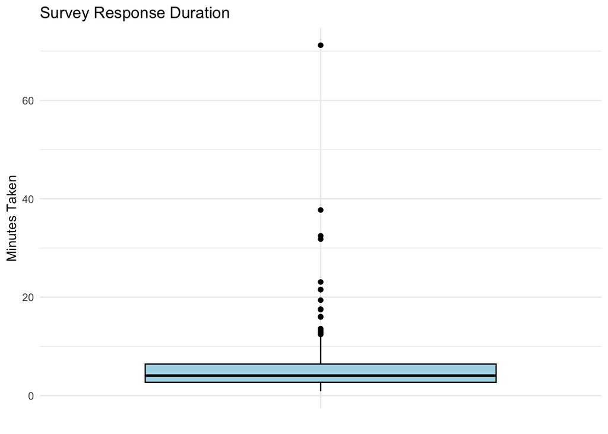

Takeaways: Because only some responses were unusually long, there is no evidence for bots present based on extremely short response times only. However, after writing post_season_ip to a new file, “post_season_cleaned_ip_addresses.csv” there are clearly still bots within the data.

*Top 6 fastest response durations for post-season respondents.*

| Respondent ID | Duration (min:sec) |
| --- | --- |
| 304720498 | 0:53 |
| 304713306 | 0:54 |
| 304713284 | 1:00 |
| 304713215 | 1:11 |
| 304724764 | 1:14 |
| 304885124 | 1:21 |

#### Combining manual- and auto-collected parameters to validate participant responses.

*Remove non-US auto-collected countries and manual zip code entries that are not 5 characters.*

Rationale: Auto-collected countries outside of the United States are unlikely given the scope and target audience of the survey. Additional manual review of row responses for non-US locations indicated bot behavior such as nonsensical free response answers.

*All non-US Post-Season Responses (n = 10).*

Non-US countries should not have filled out the zip code question. The “Anything to share” column is used as an additional verification of bot-indicating behavior. As a result of this, we can filter these rows out of the dataset further.

| Respondent ID | Country | Zip Code | Anything else to share? |
| --- | --- | --- | --- |
| 304883026 | China | 10004 | Top of the Park or A2SF, as an organization, is committed to promoting the sustainable development of parks and public spaces and improving the quality of urban life. They promote the design, construc… |
| 304892255 | China | 48104 | I really enjoy these activities and things like that |
| 304790849 | Czech Republic | 48381 | As a first time visitor to A2SF, I was really impressed with the level of musicians and other artists, the food and beer tent. It was clean and had a good vibe. |
| 304713215 | Ukraine | 48105 | no |
| 304713306 | Ukraine | 48107 | no |
| 304723120 | Ukraine | 7104 | Enjoy the music atmosphere |
| 304723498 | Ukraine | 6915 | Enjoy the atmosphere that music brings to me |
| 304741418 | Ukraine | 72701 | Rooftop Interior Room: A 700-plus square foot interior space that can accommodate up to 70 guests with year-round views of the city, perfect for family gatherings and small weddings |
| 304741907 | Ukraine | 48104 | The warmth and happiness of spending happy time with your family |
| 304745032 | Ukraine | 67758 | Food booth: Offering a variety of food and drinks to meet the needs of different tastes |

Additionally, zip codes should be 5 characters in length. When we see typos like “4103” instead of “48103”, it is possible this is a typo, but we should not assume this to be a zip code in 48103. Further filtering requires the removal of these responses.

| Respondent ID | Country | State | Zip Code |
| --- | --- | --- | --- |
| 304885041 | United States of America | Arizona | renegofdorsey@gmail.com |
| 304885502 | United States of America | California | 713499 |
| 304911308 | United States of America | California | 389-12-9046 |
| 304681059 | United States of America | Michigan | 48103-1736 |
| 304885727 | United States of America | New York | Deb Reese |
| 304911852 | United States of America | New York | 5051 |
| 304725609 | United States of America | Pennsylvania | 6042 |
| 304911504 | United States of America | Texas | Leopold Burns |

NOTE: Response ID 304681059 seems to be a valid combination of Country, State, and Zip Code, and upon reviewing the other responses, indicates a human responded. This entry is edited and will remain in the dataset, but with only the first 5 digits (48103) instead of including -1736 in the end.

Overall, zip code entries that are not 5 characters are unlikely, and few countries outside the US use postal codes.

*Determine bots using zip code and state collected data.*

Rationale: Because some United States-based responses may also be bots, we have to be creative to identify additional ones. To do this, I use a function to identify states and zip codes and determine whether the zip codes, which respondents manually inputted, match with the states/countries, which was automatically collected from respondents’ device locations.

*First six respondent ID’s and their state-zip code matching.*

Following identification of “Match” or “Not Match”, we filter the full dataset so it only contains “Match” results. Then, we will write to csv a fully cleaned file that can be used in further post-season analysis and data visualization methods.

| Respondent ID | State | Zip Code | Match? |
| --- | --- | --- | --- |
| 304882026 | Alabama | 99648 | No Match |
| 304884161 | Alabama | 59601 | No Match |
| 304884684 | Alabama | 99550 | No Match |
| 304885124 | Alabama | 35244 | Match |
| 304887014 | Alabama | 65762 | No Match |
| 304883642 | Arizona | 48109 | No Match |

*Final cleaned result. There are still some suspicious responses because the short answer does not align well with the question asked, but these are few in number.*

Notably suspect: **304885124, 304722909, 304882174, 304751759**. However, these managed to pass ALL of the following:

- Non-duplicate IP Address sources
- Normal response duration
- United States
- Zip code length is 5 characters
- State (auto-collected) and Zip code (manual-collected) match

As a result, we will leave these responses in the dataset, but should exercise caution when performing analysis.

| ID | State | Zip Code | Anything else? | Email | Match? |
| --- | --- | --- | --- | --- | --- |
| 304885124 | Alabama | 35244 | Recruit volunteers to guide the audience | janzotell82@gmail.com | Match |
| 304885234 | Arizona | 85138 | Invite more established performers | ratherp04@gmail.com | Match |
| 304882174 | California | 90017 | Hope to provide more services | myerstims1999@gmail.com | Match |
| 304751759 | Louisiana | 70112 | Let me share the content of the event Activity Content: Free Concert: Every night, different styles of music are performed, from local bands to internationally renowned artists. Movies by Moonlight: O… | laderoutenicholai@gmail.com | Match |
| 304722909 | Massachusetts | 13130 | A good musical experience is one of passion and creativity | marinogeronimo839@gmail.com | Match |
| 304677741 | Maryland | 21209 | Thank you! We were at Umich for a conference and decided to stop by. | heshyr@gmail.com | Match |

##### *The final output of this file is named, “post_season-processed.csv”.*